# Assignment 2 - Language Development in ASD - Part 1 - Explaining development

Studygroup 4

11/9/2020

#CLEAN markdown with #small comments on choises and results are made along the way while the full report can be seen in the attached document.

[See the document here](https://docs.google.com/document/d/1LtrmpRjy1SYCNhrBuOoLZX5uBSWwxAVzhSJ664kV0XU/edit?usp=sharing)

**Loading usefull packages**

```r
pacman::p_load(tidyverse, purrr, MuMIn, lmerTest)
```

**Loading the clean dataframe from last portfolio**

```r
df<- read.csv("autism_df.csv")
#removing x
df[,1] <- NULL
```

**Exploring Participants**

```r
#exploring the format of the variables
str(df)
```

```
## 'data.frame':    372 obs. of  20 variables:
##  $ SUBJ          : int  1 1 1 1 1 1 2 2 2 2 ...
##  $ ADOS1         : int  0 0 0 0 0 0 13 13 13 13 ...
##  $ nonverbalIQ1  : int  28 28 28 28 28 28 34 34 34 34 ...
##  $ verbalIQ1     : int  14 14 14 14 14 14 27 27 27 27 ...
##  $ Socialization1: int  108 108 108 108 108 108 85 85 85 85 ...
##  $ VISIT         : int  1 2 3 4 5 6 1 2 3 4 ...
##  $ Ethnicity     : chr  "White" "White" "White" "White" ...
##  $ Diagnosis     : chr  "TD" "TD" "TD" "TD" ...
##  $ Gender        : chr  "M" "M" "M" "M" ...
##  $ Age           : num  19.8 23.9 27.7 32.9 35.9 ...
##  $ ADOS          : int  0 NA NA NA 0 NA 13 NA NA NA ...
##  $ nonverbalIQ   : int  28 NA NA 33 NA 42 34 NA NA 49 ...
##  $ verbalIQ      : int  14 NA NA NA NA 44 27 NA NA NA ...
##  $ Socialization : int  108 110 109 102 107 100 85 105 77 75 ...
##  $ MOT_MLU       : num  3.62 3.86 4.32 4.42 5.21 ...
##  $ CHI_MLU       : num  1.25 1.01 1.56 2.25 3.24 ...
##  $ types_MOT     : int  378 403 455 533 601 595 317 307 351 335 ...
##  $ types_CHI     : int  14 18 97 133 182 210 146 171 262 200 ...
##  $ tokens_MOT    : int  1835 2160 2149 2260 2553 2586 1428 1270 1445 1286 ...
##  $ tokens_CHI    : int  139 148 255 321 472 686 461 562 983 674 ...
```

```r
#Mutating variables
df <- df %>%
  mutate(SUBJ = as.factor(SUBJ),
         #VISIT = as.factor(VISIT),
         Gender = as.factor(Gender),
         Diagnosis = as.factor(Diagnosis),
         Ethnicity = as.factor(Ethnicity)
      )
#Checking the difference in each condition by "splitting"/grouping Td from ASD
df %>%
  split(df$Diagnosis) %>%
  map(summary)
```

```
## $ASD
##       SUBJ         ADOS1        nonverbalIQ1     verbalIQ1     Socialization1
##  2      :  6   Min.   : 0.00   Min.   :13.00   Min.   : 8.00   Min.   : 64.00
##  4      :  6   1st Qu.:11.00   1st Qu.:25.00   1st Qu.:11.00   1st Qu.: 69.00
##  5      :  6   Median :14.00   Median :27.00   Median :16.00   Median : 76.00
##  6      :  6   Mean   :14.11   Mean   :26.89   Mean   :17.58   Mean   : 77.20
##  7      :  6   3rd Qu.:17.00   3rd Qu.:30.00   3rd Qu.:24.50   3rd Qu.: 85.25
##  18     :  6   Max.   :21.00   Max.   :42.00   Max.   :33.00   Max.   :105.00
##  (Other):140
##      VISIT                  Ethnicity   Diagnosis Gender       Age
##  Min.   :1.000   White           :130   ASD:176   F: 26   Min.   :18.77
##  1st Qu.:2.000   African American: 12   TD :  0   M:150   1st Qu.:36.88
##  Median :3.000   White/Latino    : 12                     Median :42.87
##  Mean   :3.443   Lebanese        :  6                     Mean   :43.17
##  3rd Qu.:5.000   White/Asian     :  6                     3rd Qu.:50.03
##  Max.   :6.000   Bangladeshi     :  5                     Max.   :62.40
##                  (Other)         :  5                     NA's   :4
##       ADOS       nonverbalIQ       verbalIQ     Socialization
##  Min.   : 0.0   Min.   :13.00   Min.   : 8.00   Min.   : 38.00
##  1st Qu.:11.0   1st Qu.:27.00   1st Qu.:11.75   1st Qu.: 68.00
##  Median :14.0   Median :31.00   Median :19.50   Median : 74.00
##  Mean   :13.8   Mean   :33.15   Mean   :22.62   Mean   : 77.34
##  3rd Qu.:17.0   3rd Qu.:40.50   3rd Qu.:30.00   3rd Qu.: 85.00
##  Max.   :25.0   Max.   :50.00   Max.   :50.00   Max.   :116.00
##  NA's   :117    NA's   :89      NA's   :116     NA's   :1
##     MOT_MLU         CHI_MLU        types_MOT       types_CHI
##  Min.   :1.856   Min.   :0.000   Min.   : 74.0   Min.   :  0.00
##  1st Qu.:3.222   1st Qu.:1.012   1st Qu.:284.2   1st Qu.:  9.00
##  Median :3.699   Median :1.370   Median :340.0   Median : 50.50
##  Mean   :3.657   Mean   :1.642   Mean   :338.7   Mean   : 77.21
##  3rd Qu.:4.100   3rd Qu.:2.158   3rd Qu.:397.8   3rd Qu.:144.75
##  Max.   :5.380   Max.   :4.302   Max.   :585.0   Max.   :307.00
##  NA's   :10      NA's   :10      NA's   :10      NA's   :10
##    tokens_MOT     tokens_CHI
##  Min.   : 209   Min.   :   0.0
##  1st Qu.:1388   1st Qu.:  58.0
##  Median :1805   Median : 196.0
##  Mean   :1780   Mean   : 293.6
##  3rd Qu.:2220   3rd Qu.: 482.0
##  Max.   :3182   Max.   :1293.0
```

[output cut: 28 more lines]

```
##  Min.   :2.776   Min.   :0.5584   Min.   :178.0   Min.   :  7.00
##  1st Qu.:3.805   1st Qu.:1.5577   1st Qu.:305.5   1st Qu.: 72.25
##  Median :4.117   Median :2.3202   Median :363.5   Median :131.00
##  Mean   :4.150   Mean   :2.3064   Mean   :368.6   Mean   :129.31
##  3rd Qu.:4.472   3rd Qu.:2.9095   3rd Qu.:418.8   3rd Qu.:181.00
##  Max.   :5.744   Max.   :4.3648   Max.   :601.0   Max.   :298.00
##  NA's   :10      NA's   :10       NA's   :10      NA's   :10
##    tokens_MOT     tokens_CHI
##  Min.   : 584   Min.   :  16.0
##  1st Qu.:1503   1st Qu.: 254.2
##  Median :1844   Median : 435.0
##  Mean   :1879   Mean   : 475.7
##  3rd Qu.:2264   3rd Qu.: 669.8
##  Max.   :3077   Max.   :1294.0
##  NA's   :10     NA's   :10
```

*REPORT IN DOCS*

# Hypothesis 1: The child’s MLU changes: i) over time, ii) according to diagnosis

**Ploting the data**

```
## No summary function supplied, defaulting to `mean_se()`
```

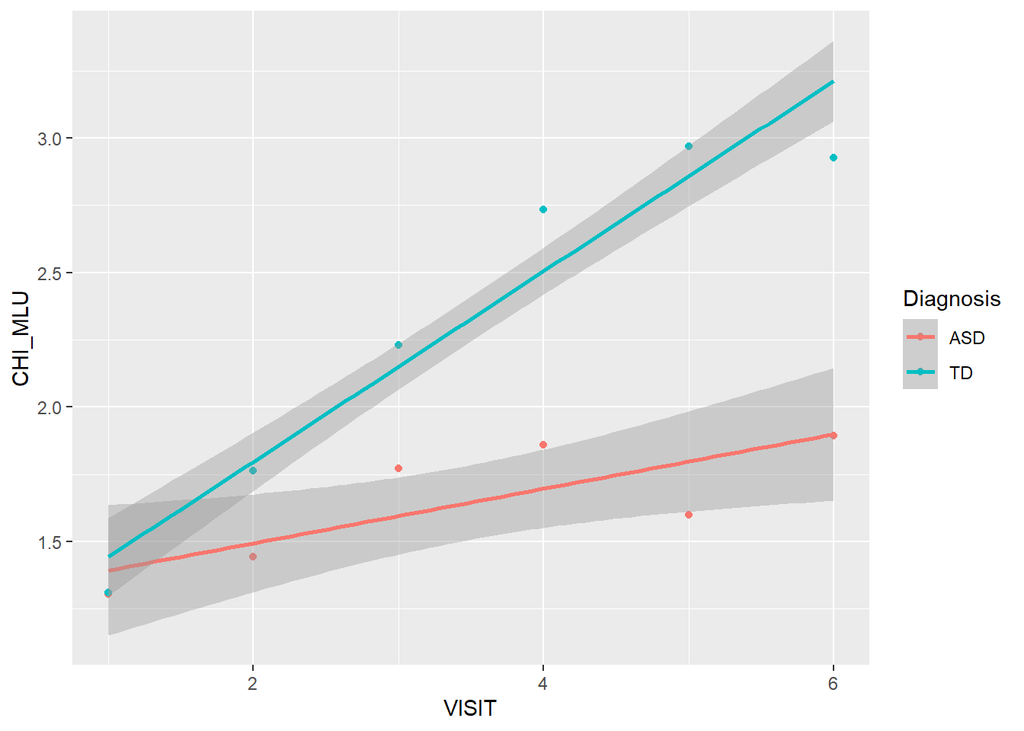

```r
#Plotting Mean length utterance for all visits for each diagnosis in linear
df %>%
  ggplot(aes(x = VISIT, y = CHI_MLU, color = Diagnosis)) +
    geom_point(stat='summary') +
    geom_smooth(method = "lm")
```

```r
#null model
null_model <- lmerTest::lmer(CHI_MLU ~ 1+(1|SUBJ),
                      df,
                     REML = FALSE)

summary(null_model)
```

```
## Linear mixed model fit by maximum likelihood . t-tests use Satterthwaite's
##   method [lmerModLmerTest]
## Formula: CHI_MLU ~ 1 + (1 | SUBJ)
##    Data: df
##
##      AIC      BIC   logLik deviance df.resid
##    831.0    842.6   -412.5    825.0      349
##
## Scaled residuals:
##      Min       1Q   Median       3Q      Max
## -2.36375 -0.60029 -0.02655  0.59406  2.59982
##
## Random effects:
##  Groups   Name        Variance Std.Dev.
##  SUBJ     (Intercept) 0.4272   0.6536
##  Residual             0.4401   0.6634
## Number of obs: 352, groups:  SUBJ, 61
##
## Fixed effects:
##             Estimate Std. Error       df t value Pr(>|t|)
## (Intercept)  1.99141    0.09089 60.92299   21.91   <2e-16 ***
## ---
## Signif. codes:  0 '***' 0.001 '**' 0.01 '*' 0.05 '.' 0.1 ' ' 1
```

```r
m0 <- lmerTest::lmer(CHI_MLU ~ Gender + Age +(1+VISIT|SUBJ)+
                       VISIT*Diagnosis,
                      df,
                     REML = FALSE)
summary(m0)
```

```
## Linear mixed model fit by maximum likelihood . t-tests use Satterthwaite's
##   method [lmerModLmerTest]
## Formula: CHI_MLU ~ Gender + Age + (1 + VISIT | SUBJ) + VISIT * Diagnosis
##    Data: df
##
##      AIC      BIC   logLik deviance df.resid
##    562.5    601.0   -271.3    542.5      336
##
## Scaled residuals:
##      Min       1Q   Median       3Q      Max
## -2.48854 -0.52868 -0.06189  0.44192  2.72904
##
## Random effects:
##  Groups   Name        Variance Std.Dev. Corr
##  SUBJ     (Intercept) 0.30720  0.5543
##           VISIT       0.01103  0.1050   -0.21
##  Residual             0.15769  0.3971
## Number of obs: 346, groups:  SUBJ, 61
##
## Fixed effects:
##                    Estimate Std. Error        df t value Pr(>|t|)
## (Intercept)         1.61242    0.54091  87.69470   2.981  0.00372 **
## GenderM             0.21774    0.20444  58.78288   1.065  0.29120
## Age                -0.01742    0.01706  92.13547  -1.021  0.30972
## VISIT               0.17542    0.07590 115.07048   2.311  0.02261 *
## DiagnosisTD        -0.40862    0.27587  85.45712  -1.481  0.14223
## VISIT:DiagnosisTD   0.24850    0.03718  61.40133   6.685 7.84e-09 ***
## ---
## Signif. codes:  0 '***' 0.001 '**' 0.01 '*' 0.05 '.' 0.1 ' ' 1
##
## Correlation of Fixed Effects:
##             (Intr) GendrM Age    VISIT  DgnsTD
## GenderM     -0.334
## Age         -0.917  0.010
## VISIT        0.818 -0.009 -0.935
## DiagnosisTD -0.832  0.045  0.781 -0.653
## VISIT:DgnTD  0.059 -0.001  0.023 -0.280 -0.278
```

```r
#Age is highly correlated with visit. Therefore, it should be removed.

m1 <- lmerTest::lmer(CHI_MLU ~ VISIT*Diagnosis+Gender+
                       (1+VISIT|SUBJ),
                      df,
                     REML = FALSE)
summary(m1)
```

```
## Linear mixed model fit by maximum likelihood . t-tests use Satterthwaite's
##   method [lmerModLmerTest]
## Formula: CHI_MLU ~ VISIT * Diagnosis + Gender + (1 + VISIT | SUBJ)
##    Data: df
##
##      AIC      BIC   logLik deviance df.resid
##    573.3    608.1   -277.7    555.3      343
##
## Scaled residuals:
##      Min       1Q   Median       3Q      Max
## -2.48637 -0.53772 -0.08284  0.44456  2.72812
##
## Random effects:
##  Groups   Name        Variance Std.Dev. Corr
##  SUBJ     (Intercept) 0.28752  0.5362
##           VISIT       0.01123  0.1060   -0.16
##  Residual             0.16062  0.4008
## Number of obs: 352, groups:  SUBJ, 61
##
## Fixed effects:
##                   Estimate Std. Error       df t value Pr(>|t|)
## (Intercept)        1.11628    0.21332 65.49037   5.233 1.89e-06 ***
## VISIT              0.10050    0.02680 61.42377   3.750 0.000394 ***
## DiagnosisTD       -0.20611    0.16851 59.31840  -1.223 0.226140
## GenderM            0.21838    0.20321 59.94455   1.075 0.286825
## VISIT:DiagnosisTD  0.25330    0.03713 61.98037   6.822 4.36e-09 ***
## ---
## Signif. codes:  0 '***' 0.001 '**' 0.01 '*' 0.05 '.' 0.1 ' ' 1
##
## Correlation of Fixed Effects:
##             (Intr) VISIT  DgnsTD GendrM
## VISIT       -0.255
## DiagnosisTD -0.461  0.322
## GenderM     -0.821  0.001  0.059
## VISIT:DgnTD  0.183 -0.722 -0.447  0.000
```

```r
# Gender has a high p -value. Let us try without it.

m2 <- lmerTest::lmer(CHI_MLU ~ VISIT*Diagnosis+
             (1+VISIT|SUBJ),
                      df,
                     REML = FALSE)
summary(m2)
```

```
## Linear mixed model fit by maximum likelihood . t-tests use Satterthwaite's
##   method [lmerModLmerTest]
## Formula: CHI_MLU ~ VISIT * Diagnosis + (1 + VISIT | SUBJ)
##    Data: df
##
##      AIC      BIC   logLik deviance df.resid
##    572.5    603.4   -278.2    556.5      344
##
## Scaled residuals:
##      Min       1Q   Median       3Q      Max
## -2.48470 -0.53248 -0.08812  0.44179  2.73712
##
## Random effects:
##  Groups   Name        Variance Std.Dev. Corr
##  SUBJ     (Intercept) 0.29420  0.5424
##           VISIT       0.01122  0.1059   -0.16
##  Residual             0.16063  0.4008
## Number of obs: 352, groups:  SUBJ, 61
##
## Fixed effects:
##                   Estimate Std. Error       df t value Pr(>|t|)
## (Intercept)        1.30459    0.12273 59.16414  10.630 2.40e-15 ***
## VISIT              0.10046    0.02680 61.43186   3.749 0.000395 ***
## DiagnosisTD       -0.21693    0.16952 59.26133  -1.280 0.205657
## VISIT:DiagnosisTD  0.25331    0.03712 61.98846   6.823 4.35e-09 ***
## ---
## Signif. codes:  0 '***' 0.001 '**' 0.01 '*' 0.05 '.' 0.1 ' ' 1
##
## Correlation of Fixed Effects:
##             (Intr) VISIT  DgnsTD
## VISIT       -0.443
## DiagnosisTD -0.724  0.321
## VISIT:DgnTD  0.320 -0.722 -0.445
```

```r
# Only with the interaction effect

m3 <- lmerTest::lmer(CHI_MLU ~ VISIT+(1+VISIT|SUBJ),
                      df,
                     REML = FALSE)

summary(m3)
```

```
## Linear mixed model fit by maximum likelihood . t-tests use Satterthwaite's
##   method [lmerModLmerTest]
## Formula: CHI_MLU ~ VISIT + (1 + VISIT | SUBJ)
##    Data: df
##
##      AIC      BIC   logLik deviance df.resid
##    605.4    628.6   -296.7    593.4      346
##
## Scaled residuals:
##      Min       1Q   Median       3Q      Max
## -2.44898 -0.57451 -0.08056  0.42981  2.71573
##
## Random effects:
##  Groups   Name        Variance Std.Dev. Corr
##  SUBJ     (Intercept) 0.30038  0.5481
##           VISIT       0.02683  0.1638   -0.24
##  Residual             0.16143  0.4018
## Number of obs: 352, groups:  SUBJ, 61
##
## Fixed effects:
##             Estimate Std. Error       df t value Pr(>|t|)
## (Intercept)  1.19062    0.08535 59.06421   13.95  < 2e-16 ***
## VISIT        0.23346    0.02452 60.80205    9.52 1.17e-13 ***
## ---
## Signif. codes:  0 '***' 0.001 '**' 0.01 '*' 0.05 '.' 0.1 ' ' 1
##
## Correlation of Fixed Effects:
##       (Intr)
## VISIT -0.431
```

```r
# VISIT as the only predictor
```

**Assessing the model**

```r
anova(m1, m2, m3)
```

```
## Data: df
## Models:
## m3: CHI_MLU ~ VISIT + (1 + VISIT | SUBJ)
## m2: CHI_MLU ~ VISIT * Diagnosis + (1 + VISIT | SUBJ)
## m1: CHI_MLU ~ VISIT * Diagnosis + Gender + (1 + VISIT | SUBJ)
##    npar    AIC    BIC  logLik deviance   Chisq Df Pr(>Chisq)
## m3    6 605.44 628.62 -296.72   593.44
## m2    8 572.46 603.37 -278.23   556.46 36.9792  2  9.334e-09 ***
## m1    9 573.32 608.09 -277.66   555.32  1.1441  1     0.2848
## ---
## Signif. codes:  0 '***' 0.001 '**' 0.01 '*' 0.05 '.' 0.1 ' ' 1
```

```r
# m2 has the best AIC and BIC score. Furthermore, the anova tells us that m2 is significantly different from m3 whereas m1 is not significantly different. Therefore, we choose to exclude gender and stay with m2.



# How about the R squared value?
r.squaredGLMM(m1)
```

```
##            R2m       R2c
## [1,] 0.3660161 0.8154333
```

```r
r.squaredGLMM(m2)
```

```
##            R2m       R2c
## [1,] 0.3571597 0.8150068
```

```r
r.squaredGLMM(m3)
```

```
##            R2m       R2c
## [1,] 0.1824133 0.8146647
```

```r
# We have chosen m2 as our model and now we want to see if this model is better than the null model
anova(m2, null_model)
```

```
## Data: df
## Models:
## null_model: CHI_MLU ~ 1 + (1 | SUBJ)
## m2: CHI_MLU ~ VISIT * Diagnosis + (1 + VISIT | SUBJ)
##            npar    AIC    BIC  logLik deviance  Chisq Df Pr(>Chisq)
## null_model    3 831.02 842.61 -412.51   825.02
## m2            8 572.46 603.37 -278.23   556.46 268.56  5  < 2.2e-16 ***
## ---
## Signif. codes:  0 '***' 0.001 '**' 0.01 '*' 0.05 '.' 0.1 ' ' 1
```

Our model is significantly better than the null model.

**Checking assumptions**

**Creating growth models**

*Visualizing quadratic*

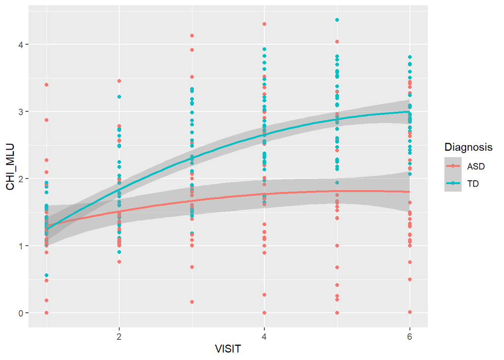

```r
qplot(VISIT,CHI_MLU, data = df, color = Diagnosis)+stat_smooth(method="lm", formula="y~poly(x,2)")
```

**Quadratic model**

```r
growth <- lmerTest::lmer(CHI_MLU ~ VISIT*Diagnosis+I(VISIT^2)+(1+I(VISIT^2)|SUBJ),
                      df,
                     REML = FALSE)
```

**Assesing the quadratic model**

*Comparing models*

```r
anova(m2, growth)
```

```
## Data: df
## Models:
## m2: CHI_MLU ~ VISIT * Diagnosis + (1 + VISIT | SUBJ)
## growth: CHI_MLU ~ VISIT * Diagnosis + I(VISIT^2) + (1 + I(VISIT^2) |
## growth:     SUBJ)
##        npar    AIC    BIC  logLik deviance  Chisq Df Pr(>Chisq)
## m2        8 572.46 603.37 -278.23   556.46
## growth    9 549.46 584.23 -265.73   531.46 25.002  1  5.727e-07 ***
## ---
## Signif. codes:  0 '***' 0.001 '**' 0.01 '*' 0.05 '.' 0.1 ' ' 1
```

growth seems to be the best fit.

# Hypothesis 2: The parents’s MLU changes: i) over time, ii) according to diagnosis

*Ploting the data*

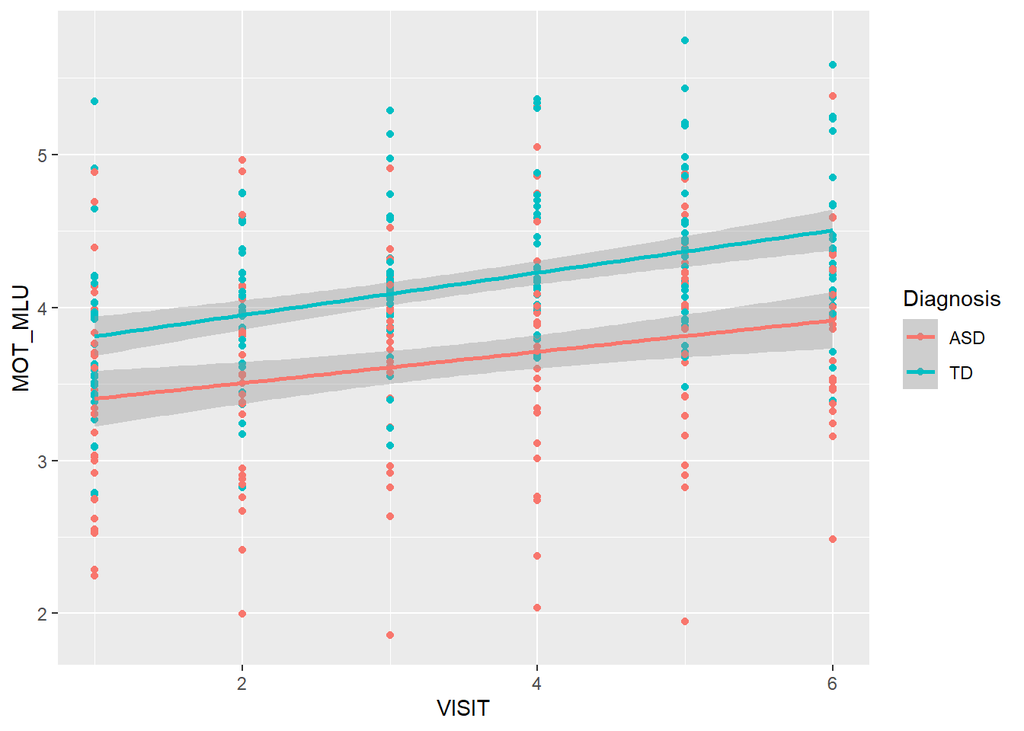

```r
#Plotting Mean length utterance for all visits for each diagnosis in linear
df %>%
  ggplot(aes(x = VISIT, y = MOT_MLU, color = Diagnosis)) +
    geom_point() +
    geom_smooth(method = "lm")
```

*Making a model*

```r
#null model
mot_null <- lmerTest::lmer(MOT_MLU ~ 1+(1|SUBJ),
                      df,
                     REML = FALSE)

summary(mot_null)
```

```
## Linear mixed model fit by maximum likelihood . t-tests use Satterthwaite's
##   method [lmerModLmerTest]
## Formula: MOT_MLU ~ 1 + (1 | SUBJ)
##    Data: df
##
##      AIC      BIC   logLik deviance df.resid
##    606.8    618.3   -300.4    600.8      349
##
## Scaled residuals:
##      Min       1Q   Median       3Q      Max
## -3.08641 -0.55417 -0.00895  0.59362  2.82192
##
## Random effects:
##  Groups   Name        Variance Std.Dev.
##  SUBJ     (Intercept) 0.2217   0.4708
##  Residual             0.2335   0.4832
## Number of obs: 352, groups:  SUBJ, 61
##
## Fixed effects:
##             Estimate Std. Error       df t value Pr(>|t|)
## (Intercept)  3.91165    0.06559 60.82484   59.64   <2e-16 ***
## ---
## Signif. codes:  0 '***' 0.001 '**' 0.01 '*' 0.05 '.' 0.1 ' ' 1
```

```r
mot_m1 <- lmerTest::lmer(MOT_MLU ~ VISIT*Diagnosis+
             (1+VISIT|SUBJ),
                      df,
                     REML = FALSE)
summary(mot_m1)
```

```
## Linear mixed model fit by maximum likelihood . t-tests use Satterthwaite's
##   method [lmerModLmerTest]
## Formula: MOT_MLU ~ VISIT * Diagnosis + (1 + VISIT | SUBJ)
##    Data: df
##
##      AIC      BIC   logLik deviance df.resid
##    513.5    544.4   -248.7    497.5      344
##
## Scaled residuals:
##      Min       1Q   Median       3Q      Max
## -2.88746 -0.58770 -0.03689  0.53919  2.96482
##
## Random effects:
##  Groups   Name        Variance Std.Dev. Corr
##  SUBJ     (Intercept) 0.32460  0.5697
##           VISIT       0.01097  0.1048   -0.69
##  Residual             0.14715  0.3836
## Number of obs: 352, groups:  SUBJ, 61
##
## Fixed effects:
##                   Estimate Std. Error       df t value Pr(>|t|)
## (Intercept)        3.31421    0.12529 59.76870  26.452  < 2e-16 ***
## VISIT              0.09922    0.02610 59.09554   3.801 0.000343 ***
## DiagnosisTD        0.35647    0.17304 59.84355   2.060 0.043752 *
## VISIT:DiagnosisTD  0.04022    0.03616 59.61514   1.112 0.270395
## ---
## Signif. codes:  0 '***' 0.001 '**' 0.01 '*' 0.05 '.' 0.1 ' ' 1
##
## Correlation of Fixed Effects:
##             (Intr) VISIT  DgnsTD
## VISIT       -0.755
## DiagnosisTD -0.724  0.547
## VISIT:DgnTD  0.545 -0.722 -0.755
```

```r
# Only with the interaction effect

mot_m2 <- lmerTest::lmer(MOT_MLU ~ VISIT+Diagnosis+
             (1+VISIT|SUBJ),
                      df,
                     REML = FALSE)

summary(mot_m2)
```

```
## Linear mixed model fit by maximum likelihood . t-tests use Satterthwaite's
##   method [lmerModLmerTest]
## Formula: MOT_MLU ~ VISIT + Diagnosis + (1 + VISIT | SUBJ)
##    Data: df
##
##      AIC      BIC   logLik deviance df.resid
##    512.7    539.8   -249.4    498.7      345
##
## Scaled residuals:
##      Min       1Q   Median       3Q      Max
## -2.89517 -0.59461 -0.02917  0.53790  3.00471
##
## Random effects:
##  Groups   Name        Variance Std.Dev. Corr
##  SUBJ     (Intercept) 0.32943  0.5740
##           VISIT       0.01135  0.1065   -0.70
##  Residual             0.14723  0.3837
## Number of obs: 352, groups:  SUBJ, 61
##
## Fixed effects:
##             Estimate Std. Error       df t value Pr(>|t|)
## (Intercept)  3.23810    0.10541 80.04973  30.720  < 2e-16 ***
## VISIT        0.12024    0.01823 59.52730   6.595 1.26e-08 ***
## DiagnosisTD  0.50193    0.11334 60.91617   4.429 4.01e-05 ***
## ---
## Signif. codes:  0 '***' 0.001 '**' 0.01 '*' 0.05 '.' 0.1 ' ' 1
##
## Correlation of Fixed Effects:
##             (Intr) VISIT
## VISIT       -0.627
## DiagnosisTD -0.566  0.003
```

```r
mot_m3 <- lmerTest::lmer(MOT_MLU ~ VISIT+(1+VISIT|SUBJ),
                      df,
                     REML = FALSE)

summary(mot_m3)
```

```
## Linear mixed model fit by maximum likelihood . t-tests use Satterthwaite's
##   method [lmerModLmerTest]
## Formula: MOT_MLU ~ VISIT + (1 + VISIT | SUBJ)
##    Data: df
##
##      AIC      BIC   logLik deviance df.resid
##    527.4    550.6   -257.7    515.4      346
##
## Scaled residuals:
##      Min       1Q   Median       3Q      Max
## -2.91830 -0.59032 -0.03879  0.56572  2.96334
##
## Random effects:
##  Groups   Name        Variance Std.Dev. Corr
##  SUBJ     (Intercept) 0.35562  0.5963
##           VISIT       0.01125  0.1060   -0.59
##  Residual             0.14741  0.3839
## Number of obs: 352, groups:  SUBJ, 61
##
## Fixed effects:
##             Estimate Std. Error       df t value Pr(>|t|)
## (Intercept)  3.50251    0.08934 60.22266   39.20  < 2e-16 ***
## VISIT        0.11991    0.01820 59.63373    6.59 1.28e-08 ***
## ---
## Signif. codes:  0 '***' 0.001 '**' 0.01 '*' 0.05 '.' 0.1 ' ' 1
##
## Correlation of Fixed Effects:
##       (Intr)
## VISIT -0.687
```

```r
# VISIT as the only predictor
```

*Assessing the model*

```r
anova(mot_null, mot_m1, mot_m2, mot_m3)
```

```
## Data: df
## Models:
## mot_null: MOT_MLU ~ 1 + (1 | SUBJ)
## mot_m3: MOT_MLU ~ VISIT + (1 + VISIT | SUBJ)
## mot_m2: MOT_MLU ~ VISIT + Diagnosis + (1 + VISIT | SUBJ)
## mot_m1: MOT_MLU ~ VISIT * Diagnosis + (1 + VISIT | SUBJ)
##          npar    AIC    BIC  logLik deviance  Chisq Df Pr(>Chisq)
## mot_null    3 606.76 618.35 -300.38   600.76
## mot_m3      6 527.44 550.62 -257.72   515.44 85.321  3  < 2.2e-16 ***
## mot_m2      7 512.71 539.75 -249.35   498.71 16.728  1  4.314e-05 ***
## mot_m1      8 513.48 544.39 -248.74   497.48  1.227  1      0.268
## ---
## Signif. codes:  0 '***' 0.001 '**' 0.01 '*' 0.05 '.' 0.1 ' ' 1
```

```r
#Let us check r squared
r.squaredGLMM(mot_null)
```

```
##      R2m       R2c
## [1,]   0 0.4870039
```

```r
r.squaredGLMM(mot_m1)
```

```
##            R2m       R2c
## [1,] 0.2292245 0.6753041
```

```r
r.squaredGLMM(mot_m2)
```

```
##            R2m       R2c
## [1,] 0.2296138 0.6762255
```

```r
r.squaredGLMM(mot_m3)
```

```
##            R2m       R2c
## [1,] 0.0924636 0.6748082
```

**Checking the model**

**Creating growth models**